# Biostat 212a Homework 2

Due Feb 6, 2024 @ 11:59PM

Author

Kathy Hoang and UID:506333118

Published

February 6, 2024

## 1 ISL Exercise 4.8.1 (10pts)

1. Using a little bit of algebra, prove that (4.2) is equivalent to (4.3). In other words, the logistic function representation and logit representation for the logistic regression model are equivalent.

Note: 4.2 logistic function representation and 4.3 logit representation can be found on page 134 in ISL book.

$$\text{Show that} \ p(X) = \frac{ e^{\beta_0 + \beta_1X}}{1 +{ e^{\beta_0 + \beta_1X} }} =
\text{is equivalent to} \ \left( \frac{p(X)}{1-p(X)} \right) = e^{\beta_0 + \beta_1X}$$
Starting with the 4.2 logstic function representation we have: $$
$$\begin{align*}
\ p(X) &= \frac{ e^{\beta_0 + \beta_1X}}{1 +{ e^{\beta_0 + \beta_1X} }} \\
\text{Let} \ X &= e^{\beta_0 + \beta_1X} \\
\text{Then} \ p(X) &= \frac{X}{1 +{X}} \\
p(X)(1 +X) &= {X} &\text{ Multiply both sides by (1+X)} \\
p(X)(1) + p(X)(X) &= {X} &\text{ Distribute p(x)} \\
p(X) &= {X} -p(X)(X) &\text{ Subtract p(X)(X) from both sides} \\
p(X) &= {X}(1-p(X)) &\text{ Factor out X} \\
\frac{p(X)}{(1-p(X))} &= {X} &\text{ Divide both sides by 1-p(X)} \\
\frac{p(X)}{(1-p(X))} &= e^{\beta_0 + \beta_1} &\text{ Substitute back in X} \\
\end{align*}$$
$$ Thus, we have arrived at the 4.3 logit representation. We have shown that the logistic function representation and logit representation for the logistic regression model are equivalent.

## 2 ISL Exercise 4.8.6 (10pts)

6. Suppose we collect data for a group of students in a statistics class with variables X1 = hours studied, X2 = undergrad GPA, and Y = receive an A. We fit a logistic regression and produce estimated coefficient, βˆ0 = −6, βˆ1 = 0.05, βˆ2 = 1.

### 2.1 4.8.6 a.

1. Estimate the probability that a student who studies for 40 h and has an undergrad GPA of 3.5 gets an A in the class.

$$\begin{align}
X_1 &= 40, X_2 =3.5 \\
\beta_0 &= -6, \beta_1 = 0.05, \beta_2 = 1 \\
p(X) &= \frac{ e^{\beta_0 + \beta_1X_1 + \beta_2X_2}}{1 +{ e^{\beta_0 + \beta_1X_1 + \beta_2X_2} }} \\
p(X) &= \frac{ e^{-6 + (0.05*40) + (1*3.5)}}{1 +{ e^{-6 + (0.5*40) + (1*3.5)} }} \\
p(X) &= \frac{0.6065307}{1 + 0.6065307} \\
p(X) &= 0.3775407 \\
&= 0.38
\end{align}$$
Note: ran in termnal:exp(-6 + (0.05*40) + (1*3.5)) -> 0.6065307 and 0.6065307/(1+0.6065307) -> 0.3775407

The probability that a student who studies for 40 h and has an undergrad GPA of 3.5 gets an A in the class is about 38%.

### 2.2 4.8.6 b.

2. How many hours would the student in part (a) need to study to have a 50 % chance of getting an A in the class?

$$\begin{align}
p &= 0.5, X_1 = ? \\
\beta_0 &= -6, \beta_1 = 0.05, \beta_2 = 1 \\
\frac{p(X)}{1-p(X)} &= {e^{\beta_0 + \beta_1X_1 + \beta_2X_2}} \\
log(\frac{p(X)}{1-p(X)}) &= \beta_0 + \beta_1X_1 + \beta_2X_2 \\
log(\frac{0.5}{1-0.5}) &= -6 + (0.05*X_1) + (1*3.5) \\
log(1) &= -6 + (0.05*X_1) + (1*3.5) \\
0 &= -6 + (0.05*X_1) + (1*3.5) \\
6 &= 0.05*X_1 + 3.5 \\
2.5 &= 0.05*X_1 \\
X_1 &= 50 \\
\end{align}$$
## ISL Exercise 4.8.9 (10pts)

9. This problem has to do with odds.

### 2.3 4.8.9 a.

1. On average, what fraction of people with an odds of 0.37 of defaulting on their credit card payment will in fact default?
   $$\begin{align}
   \text{Odds} &= \frac{p}{1-p} = 0.37 \\
   \text{Inverting this relationship: }
   p &= \frac{0.37}{1+0.37} \\
   &= \frac{0.37}{1.37} \\
   &= 0.27
   \end{align}$$
   On average, 27% of people with an odds of 0.37 of defaulting on their credit card payment will in fact default.

### 2.4 4.8.9 b.

2. Suppose that an individual has a 16% chance of defaulting on her credit card payment. What are the odds that she will default?

$$\begin{align}
p &= 0.16 \\
\text{Odds} &= \frac{0.16}{1-0.16} \\
&= \frac{0.16}{0.84} \\
&= 0.1904762 \\
&= 0.19
\end{align}$$
The odds that she will default with 16% chance of defaulting her credit card is 0.19.

## 3 ISL Exercise 4.8.13 (a)-(i) (50pts)

This question should be answered using the Weekly data set, which is part of the ISLR2 package. This data is similar in nature to the Smarket data from this chapter’s lab, except that it contains 1,089 weekly returns for 21 years, from the beginning of 1990 to the end of 2010.

```r
library(ISLR2)
```

Link to documentation on Weekly dataset: https://www.rdocumentation.org/packages/ISLR/versions/1.4/topics/Weekly

### 3.1 4.8.13 a.

1. Produce some numerical and graphical summaries of the Weekly data. Do there appear to be any patterns?

```r
#Numeric Summaries

#Summary
summary(Weekly)
```

```
      Year           Lag1               Lag2               Lag3
 Min.   :1990   Min.   :-18.1950   Min.   :-18.1950   Min.   :-18.1950
 1st Qu.:1995   1st Qu.: -1.1540   1st Qu.: -1.1540   1st Qu.: -1.1580
 Median :2000   Median :  0.2410   Median :  0.2410   Median :  0.2410
 Mean   :2000   Mean   :  0.1506   Mean   :  0.1511   Mean   :  0.1472
 3rd Qu.:2005   3rd Qu.:  1.4050   3rd Qu.:  1.4090   3rd Qu.:  1.4090
 Max.   :2010   Max.   : 12.0260   Max.   : 12.0260   Max.   : 12.0260
      Lag4               Lag5              Volume            Today
 Min.   :-18.1950   Min.   :-18.1950   Min.   :0.08747   Min.   :-18.1950
 1st Qu.: -1.1580   1st Qu.: -1.1660   1st Qu.:0.33202   1st Qu.: -1.1540
 Median :  0.2380   Median :  0.2340   Median :1.00268   Median :  0.2410
 Mean   :  0.1458   Mean   :  0.1399   Mean   :1.57462   Mean   :  0.1499
 3rd Qu.:  1.4090   3rd Qu.:  1.4050   3rd Qu.:2.05373   3rd Qu.:  1.4050
 Max.   : 12.0260   Max.   : 12.0260   Max.   :9.32821   Max.   : 12.0260
 Direction
 Down:484
 Up  :605
```

```r
#Structure
str(Weekly)
```

```
'data.frame':   1089 obs. of  9 variables:
 $ Year     : num  1990 1990 1990 1990 1990 1990 1990 1990 1990 1990 ...
 $ Lag1     : num  0.816 -0.27 -2.576 3.514 0.712 ...
 $ Lag2     : num  1.572 0.816 -0.27 -2.576 3.514 ...
 $ Lag3     : num  -3.936 1.572 0.816 -0.27 -2.576 ...
 $ Lag4     : num  -0.229 -3.936 1.572 0.816 -0.27 ...
 $ Lag5     : num  -3.484 -0.229 -3.936 1.572 0.816 ...
 $ Volume   : num  0.155 0.149 0.16 0.162 0.154 ...
 $ Today    : num  -0.27 -2.576 3.514 0.712 1.178 ...
 $ Direction: Factor w/ 2 levels "Down","Up": 1 1 2 2 2 1 2 2 2 1 ...
```

```r
#Correlation Matrix
cor(Weekly[, -9])
```

```
              Year         Lag1        Lag2        Lag3         Lag4
Year    1.00000000 -0.032289274 -0.03339001 -0.03000649 -0.031127923
Lag1   -0.03228927  1.000000000 -0.07485305  0.05863568 -0.071273876
Lag2   -0.03339001 -0.074853051  1.00000000 -0.07572091  0.058381535
Lag3   -0.03000649  0.058635682 -0.07572091  1.00000000 -0.075395865
Lag4   -0.03112792 -0.071273876  0.05838153 -0.07539587  1.000000000
Lag5   -0.03051910 -0.008183096 -0.07249948  0.06065717 -0.075675027
Volume  0.84194162 -0.064951313 -0.08551314 -0.06928771 -0.061074617
Today  -0.03245989 -0.075031842  0.05916672 -0.07124364 -0.007825873
               Lag5      Volume        Today
Year   -0.030519101  0.84194162 -0.032459894
Lag1   -0.008183096 -0.06495131 -0.075031842
Lag2   -0.072499482 -0.08551314  0.059166717
Lag3    0.060657175 -0.06928771 -0.071243639
Lag4   -0.075675027 -0.06107462 -0.007825873
Lag5    1.000000000 -0.05851741  0.011012698
Volume -0.058517414  1.00000000 -0.033077783
Today   0.011012698 -0.03307778  1.000000000
```

```r
#exclude the Direction column (9) because it is categorical and it will error that it needs to be numeric
```

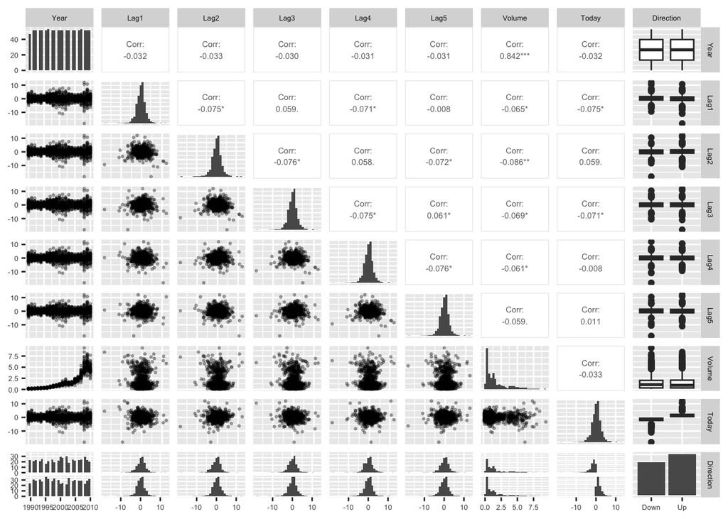

```r
#Graphical Summaries
library(GGally)

Weekly %>% ggpairs(progress = FALSE, #hide progress output
                   lower = list(continuous = wrap("points", alpha = 0.3, size=0.5)), diag=list(continuous='barDiag'),
                   upper = list(continuous = wrap("cor", size = 2))) + theme(axis.text = element_text(size = 5),
                  #change axis
                  strip.text.x = element_text(size = 5), #change row text label sizes
                  strip.text.y = element_text(size = 5)) #change col text label sizes
```

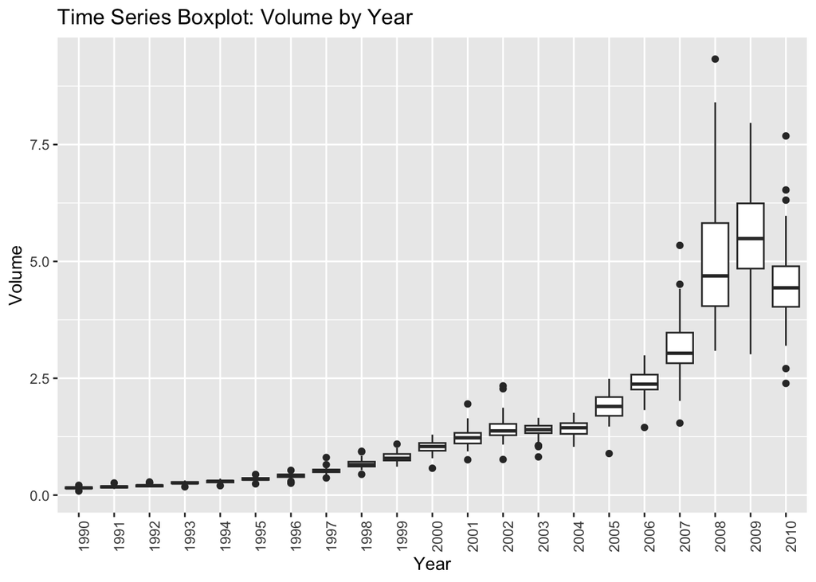

```r
#Time Series Plot
year_factor <- as.factor(Weekly$Year) #don't overwrite original dataset! will have other issues running, had to rm(Weekly) and reload the ISLR2 library
ggplot(Weekly, aes(x = year_factor, y = Volume)) + geom_boxplot() + theme(axis.text.x = element_text(angle = 90, hjust = 1)) + labs(title = "Time Series Boxplot: Volume by Year", x = "Year", y = "Volume")
```

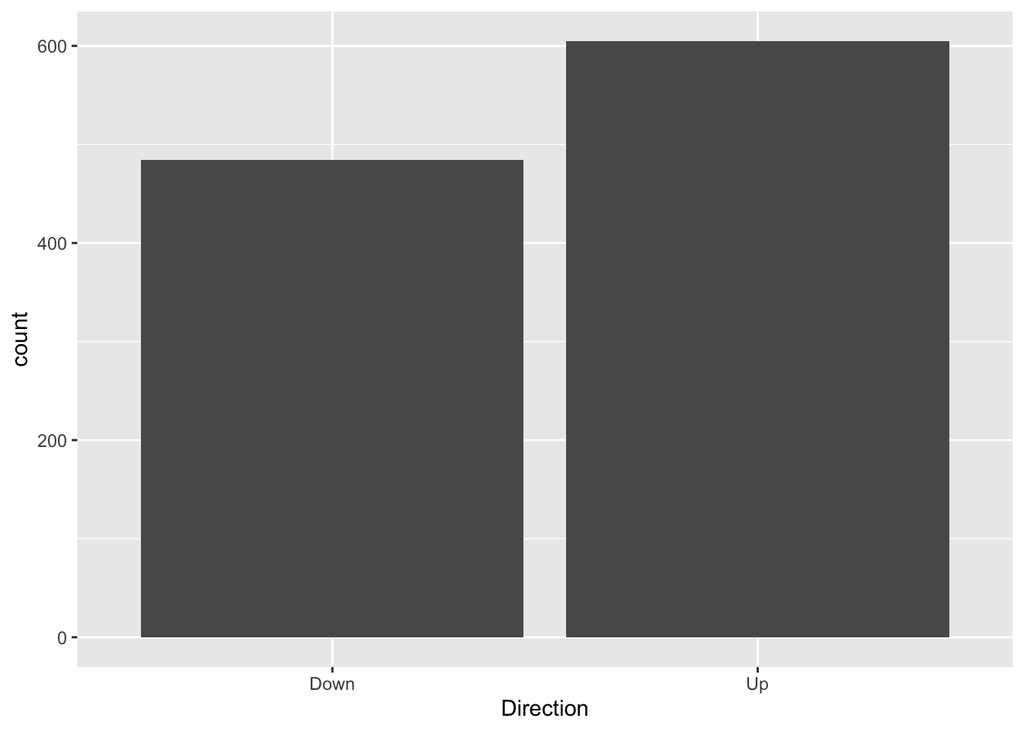

```r
#Direction Bar Plot (closer look at Direction bar plot from ggpairs)
ggplot(Weekly, aes(x = Direction)) + geom_bar()
```

Patterns:

There are no strong correlations between most of the variables. The scatter plots show no strong linear relationships between the variables, and all of the coefficients are very low (<0.1) except for the correlation between Year and Volume. These two variables have a strong positive correlation coefficient of 0.841942, which is also reflected in the time series plot above. Most of the other correlation coefficients are negative, but really close to 0.

The bar plots show that the number of Up days is slightly more than the number of Down days, meaning that there were more times when the stock market was going up in a positive direction.

The distribution of Volume is right-skewed.

### 3.2 4.8.13 b.

2. Use the full data set to perform a logistic regression with Direction as the response and the five lag variables plus Volume as predictors. Use the summary function to print the results. Do any of the predictors appear to be statistically significant? If so, which ones?

```r
#Logistic Regression
fit <- glm(Direction ~ Lag1 + Lag2 + Lag3 + Lag4 + Lag5 + Volume, data = Weekly, family = binomial)
summary(fit)
```

```
Call:
glm(formula = Direction ~ Lag1 + Lag2 + Lag3 + Lag4 + Lag5 +
    Volume, family = binomial, data = Weekly)

Coefficients:
            Estimate Std. Error z value Pr(>|z|)
(Intercept)  0.26686    0.08593   3.106   0.0019 **
Lag1        -0.04127    0.02641  -1.563   0.1181
Lag2         0.05844    0.02686   2.175   0.0296 *
Lag3        -0.01606    0.02666  -0.602   0.5469
Lag4        -0.02779    0.02646  -1.050   0.2937
Lag5        -0.01447    0.02638  -0.549   0.5833
Volume      -0.02274    0.03690  -0.616   0.5377
---
Signif. codes:  0 '***' 0.001 '**' 0.01 '*' 0.05 '.' 0.1 ' ' 1

(Dispersion parameter for binomial family taken to be 1)

    Null deviance: 1496.2  on 1088  degrees of freedom
Residual deviance: 1486.4  on 1082  degrees of freedom
AIC: 1500.4

Number of Fisher Scoring iterations: 4
```

Yes, Lag2 appears to be statistically significant as the p-value for Lag2 is 0.0296 which is less than 0.05.

### 3.3 4.8.13 c.

3. Compute the confusion matrix and overall fraction of correct predictions. Explain what the confusion matrix is telling you about the types of mistakes made by logistic regression.

```r
#Generate probabilities for each observation using the fit model
probs <- predict(fit, type = "response")

#Create pred vector with "Down" as default
pred <- rep("Down", length(probs))
#Change pred to "Up" if the probability is greater than 0.5
pred[probs > 0.5] <- "Up"

#actual direction values of entire dataset
actual_direction <- Weekly$Direction

#Confusion Matrix - compare pred to actual Direction
table(pred, actual_direction)
```

```
      actual_direction
pred   Down  Up
  Down   54  48
  Up    430 557
```

```r
#Overall Fraction of Correct Predictions
mean(pred == actual_direction)
```

```
[1] 0.5610652
```

```r
length(probs) #total number (sum of all)
```

```
[1] 1089
```

### 3.4 4.8.13 d.

4. Now fit the logistic regression model using a training data period from 1990 to 2008, with Lag2 as the only predictor. Compute the confusion matrix and the overall fraction of correct predictions for the held out data (that is, the data from 2009 and 2010).

```r
#Lowest year is 1990 and highest year is 2010
min(Weekly$Year) #1990
```

```
[1] 1990
```

```r
max(Weekly$Year) #2010
```

```
[1] 2010
```

```r
##Create training and test sets
training_set <- Weekly[Weekly$Year < 2009, ] #since we know 1990 is the lowest year we can use this cutoff
test_set <- Weekly[Weekly$Year >= 2009, ] #2009-2010 data, since we know 2010 is the highest year

#Fit the model with Lad 2 as the only predictor
fit_lag2 <- glm(Direction ~ Lag2, data = training_set, family = binomial)
summary(fit_lag2)
```

```
Call:
glm(formula = Direction ~ Lag2, family = binomial, data = training_set)

Coefficients:
            Estimate Std. Error z value Pr(>|z|)
(Intercept)  0.20326    0.06428   3.162  0.00157 **
Lag2         0.05810    0.02870   2.024  0.04298 *
---
Signif. codes:  0 '***' 0.001 '**' 0.01 '*' 0.05 '.' 0.1 ' ' 1

(Dispersion parameter for binomial family taken to be 1)

    Null deviance: 1354.7  on 984  degrees of freedom
Residual deviance: 1350.5  on 983  degrees of freedom
AIC: 1354.5

Number of Fisher Scoring iterations: 4
```

```r
#Predict - Generate probabilities for each observation using the fit model
probs_lag2 <- predict(fit_lag2, test_set, type = "response")
#Type = response because it's probability scaled 0 to 1 (default type is link which is log odds)

#Create pred vector with "Down" as default
pred_lag2 <- rep("Down", length(probs_lag2))
#Change pred to "Up" if the probability is greater than 0.5
pred_lag2[probs_lag2 > 0.5] <- "Up"

#actual Y direction values of test set
actual_Y = test_set$Direction
#Confusion Matrix - compare pred to actual Direction
table(pred_lag2, actual_Y)
```

```
         actual_Y
pred_lag2 Down Up
     Down    9  5
     Up     34 56
```

```r
#Overall Fraction of Correct Predictions
mean(pred_lag2 == actual_Y)
```

```
[1] 0.625
```

```r
length(probs_lag2)
```

```
[1] 104
```

```r
# ran in terminal: sum(9,5,34,56) = 104 to check
```

### 3.5 4.8.13 e.

5. Repeat (d) using LDA.

```r
#Load MASS library to use lda()
library(MASS)

#Fit the model with Lad 2 as the only predictor
fit_lag2_lda <- lda(Direction ~ Lag2, data = training_set)
#note: don't need to specify family = binomial because lda() is a classification model

#LDA is a classification model so we predict the class (need to specify $class)
pred_lag2_lda <- predict(fit_lag2_lda, test_set)$class
summary(pred_lag2_lda)
```

```
Down   Up
  14   90
```

```r
#Confusion Matrix - compare pred to actual Direction
table(pred_lag2_lda, test_set$Direction)
```

```
pred_lag2_lda Down Up
         Down    9  5
         Up     34 56
```

```r
#Overall Fraction of Correct Predictions
mean(pred_lag2_lda == test_set$Direction)
```

```
[1] 0.625
```

The LDA model achieved similar results to the logistic regression model, with the same confusion matrix and overall fraction of correct predictions of 0.625

### 3.6 4.8.13 f.

6. Repeat (d) using QDA.

```r
#Fit the model with Lad 2 as the only predictor
fit_lag2_qda <- qda(Direction ~ Lag2, data = training_set)
#note: don't need to specify family = binomial because qda() is a classification model

#Predict - Generate probabilities
pred_lag2_qda <- predict(fit_lag2_qda, test_set)$class
summary(pred_lag2_qda)
```

```
Down   Up
   0  104
```

```r
#Confusion Matrix - compare pred to actual Direction
table(pred_lag2_qda, actual_Y)
```

```
             actual_Y
pred_lag2_qda Down Up
         Down    0  0
         Up     43 61
```

```r
mean(pred_lag2_qda == actual_Y)
```

```
[1] 0.5865385
```

```r
length(pred_lag2_qda)
```

```
[1] 104
```

The confusion matrix shows that the QDA model always chose “Up” as the prediction, and the overall fraction of correct predictions is 61/104= 0.5865. This implies that when the stock market was going down, the QDA model always predicted that it would go up and was right 0% of the time. When the stock market was going up it was right 100% of the time. Despite this, the QDA model performed only slightly worse than the LDA and logistic regression models (0.5865 vs 0.625).

### 3.7 4.8.13 g.

7. Repeat (d) using KNN with K = 1.

```r
#Load class library to use knn()
library(class)

#Create training and test sets
train_X <- as.matrix(training_set$Lag2)
test_X <- as.matrix(test_set$Lag2)
train_Y_labels <- training_set$Direction
set.seed(1)
pred_lag2_knn <- knn(train = train_X, test = test_X, cl = train_Y_labels, k = 1)

#Model Evaluation
actual_Y <- test_set$Direction

#Confusion Matrix
table(pred_lag2_knn, actual_Y)
```

```
             actual_Y
pred_lag2_knn Down Up
         Down   21 30
         Up     22 31
```

```r
#Overall Fraction of Correct Predictions
mean(pred_lag2_knn == actual_Y)
```

```
[1] 0.5
```

With an overall fraction of correct predictions of 0.5, the KNN model with K=1 performed the worst out of all the models. The confusion matrix shows that the KNN model made 21+31= 52 correct predictions and 22+30 = 52 incorrect predictions. When the market is actually up, the KNN model predicted it correctly 31/(30+31) = 50.82% of the time. When the market is actually down, the KNN model predicted it correctly 21/(21+22) = 48.84% of the time. Perhaps a more optimal k is needed to improve the performance of the KNN model.

### 3.8 4.8.13 h.

8. Repeat (d) using naive Bayes.

```r
#Load e1071 library to use naiveBayes()
library(e1071)

naiveBayes_lag2_fit <- naiveBayes(Direction ~ Lag2, data = training_set)
naiveBayes_lag2_pred <- predict(naiveBayes_lag2_fit, test_set)

table(naiveBayes_lag2_pred, actual_Y)
```

```
                    actual_Y
naiveBayes_lag2_pred Down Up
                Down    0  0
                Up     43 61
```

```r
mean(naiveBayes_lag2_pred == actual_Y)
```

```
[1] 0.5865385
```

The naive Bayes model achieved similar results to the QDA model, obtaining the same confusion matrix and overall fraction of correct predictions of 0.58.

### 3.9 4.8.13 i.

1. Which of these methods appears to provide the best results on this data?

The best performing models were Logistic Regression and LDA, with an overall fraction of correct predictions of 0.625. The QDA model and naive Bayes model performed slightly worse with an overall fraction of correct predictions of 0.5865. The KNN model with K=1 performed the worst with an overall fraction of correct predictions of 0.5.

## 4 Bonus question: ISL Exercise 4.8.13 Part (j) (30pts)

10. Experiment with different combinations of predictors, including possible transformations and interactions, for each of the methods. Report the variables, method, and associated confusion matrix that appears to provide the best results on the held out data. Note that you should also experiment with values for K in the KNN classifier.

**Answer**

Although the plots I generated from ggpairs earlier in my exploratory data analysis showed that there were no strong correlation between the variables, I will experiment with the interaction effect of consecutive Lag variables to see if it will improve the performance of the logistic regression model. I choose these variables because I believe that the percentage return for the week prior may have an effect on the percentage return for the subsequent week. For example, I chose to explore different combinations of the interaction effects of Today, Lag1, Lag2, Lag3, and Lag4 because I believe that Lag 4 may influence Lag 3, Lag 3 on Lag 2, …, and overall have an effect on the current week (Today).

**Logistic Regression with Perfect Prediction/Quasi-Complete Separation**

```r
#Logistic Regression with Interaction Effect of Today and 4 previous weeks (Today, Lag1, Lag2, Lag3, and Lag4)
fit_logistic_interaction_3 <- glm(Direction ~ Today*Lag1*Lag2*Lag3*Lag4, data = training_set, family = binomial)
summary(fit_logistic_interaction_3)
```

```
Call:
glm(formula = Direction ~ Today * Lag1 * Lag2 * Lag3 * Lag4,
    family = binomial, data = training_set)

Coefficients:
                            Estimate Std. Error   z value Pr(>|z|)
(Intercept)                2.998e+13  2.216e+06  13527942   <2e-16 ***
Today                      8.138e+14  1.077e+06 755699477   <2e-16 ***
Lag1                      -6.908e+12  1.091e+06  -6331510   <2e-16 ***
Lag2                       1.173e+13  1.106e+06  10602169   <2e-16 ***
Lag3                      -1.573e+12  1.106e+06  -1421382   <2e-16 ***
Lag4                       1.674e+12  1.103e+06   1518408   <2e-16 ***
Today:Lag1                 5.410e+13  4.040e+05 133904492   <2e-16 ***
Today:Lag2                 2.121e+13  4.817e+05  44023097   <2e-16 ***
Lag1:Lag2                  3.512e+12  4.236e+05   8292648   <2e-16 ***
Today:Lag3                 2.217e+13  4.252e+05  52134136   <2e-16 ***
Lag1:Lag3                  4.066e+12  4.824e+05   8428001   <2e-16 ***
Lag2:Lag3                  1.161e+13  3.911e+05  29674501   <2e-16 ***
Today:Lag4                 5.091e+13  4.377e+05 116331953   <2e-16 ***
Lag1:Lag4                 -5.767e+12  4.335e+05 -13304224   <2e-16 ***
Lag2:Lag4                 -1.581e+12  4.748e+05  -3331038   <2e-16 ***
Lag3:Lag4                  8.342e+11  3.484e+05   2394326   <2e-16 ***
Today:Lag1:Lag2           -5.127e+12  1.318e+05 -38897660   <2e-16 ***
Today:Lag1:Lag3           -6.884e+12  1.677e+05 -41050375   <2e-16 ***
Today:Lag2:Lag3            1.134e+13  1.386e+05  81790277   <2e-16 ***
Lag1:Lag2:Lag3            -6.067e+12  1.344e+05 -45138929   <2e-16 ***
Today:Lag1:Lag4            1.999e+12  1.395e+05  14327979   <2e-16 ***
Today:Lag2:Lag4            6.033e+12  1.709e+05  35305066   <2e-16 ***
Lag1:Lag2:Lag4             2.227e+12  1.479e+05  15061127   <2e-16 ***
Today:Lag3:Lag4           -5.340e+12  1.180e+05 -45245771   <2e-16 ***
Lag1:Lag3:Lag4             5.361e+11  1.536e+05   3490116   <2e-16 ***
Lag2:Lag3:Lag4             5.137e+12  9.849e+04  52157566   <2e-16 ***
Today:Lag1:Lag2:Lag3      -1.901e+12  3.926e+04 -48408744   <2e-16 ***
Today:Lag1:Lag2:Lag4      -1.346e+12  3.701e+04 -36379066   <2e-16 ***
Today:Lag1:Lag3:Lag4      -1.879e+12  2.969e+04 -63264971   <2e-16 ***
Today:Lag2:Lag3:Lag4       1.979e+12  3.699e+04  53485801   <2e-16 ***
Lag1:Lag2:Lag3:Lag4       -8.405e+11  3.458e+04 -24302226   <2e-16 ***
Today:Lag1:Lag2:Lag3:Lag4 -1.364e+11  8.177e+03 -16680529   <2e-16 ***
---
Signif. codes:  0 '***' 0.001 '**' 0.01 '*' 0.05 '.' 0.1 ' ' 1

(Dispersion parameter for binomial family taken to be 1)

    Null deviance: 1354.71  on 984  degrees of freedom
Residual deviance:  865.05  on 953  degrees of freedom
AIC: 929.05

Number of Fisher Scoring iterations: 12
```

```r
probs_logistic_interaction_3 <- predict(fit_logistic_interaction_3, test_set, type = "response")
pred_logistic_interaction_3 <- rep("Down", length(probs_logistic_interaction_3))
pred_logistic_interaction_3[probs_logistic_interaction_3 > 0.5] <- "Up"
table(pred_logistic_interaction_3, actual_Y)
```

```
                           actual_Y
pred_logistic_interaction_3 Down Up
                       Down   41  3
                       Up      2 58
```

```r
mean(pred_logistic_interaction_3 == actual_Y)
```

```
[1] 0.9519231
```

```r
#0.9519231
```

```r
#Logistic Regression with Interaction Effect of Today and 2 previous weeks (Today, Lag1, Lag2)
fit_logistic_interaction_2 <- glm(Direction ~ Today*Lag1*Lag2, data = training_set, family = binomial)
summary(fit_logistic_interaction_2)
```

```
Call:
glm(formula = Direction ~ Today * Lag1 * Lag2, family = binomial,
    data = training_set)

Coefficients:
                  Estimate Std. Error    z value Pr(>|z|)
(Intercept)     -9.469e+12  2.157e+06   -4390584   <2e-16 ***
Today            1.048e+15  1.040e+06 1007546888   <2e-16 ***
Lag1            -2.413e+13  1.015e+06  -23777958   <2e-16 ***
Lag2            -8.906e+12  9.750e+05   -9134294   <2e-16 ***
Today:Lag1       1.077e+14  2.945e+05  365542755   <2e-16 ***
Today:Lag2       2.252e+13  2.974e+05   75702159   <2e-16 ***
Lag1:Lag2        5.286e+11  2.465e+05    2144633   <2e-16 ***
Today:Lag1:Lag2  6.516e+12  5.898e+04  110483327   <2e-16 ***
---
Signif. codes:  0 '***' 0.001 '**' 0.01 '*' 0.05 '.' 0.1 ' ' 1

(Dispersion parameter for binomial family taken to be 1)

    Null deviance: 1354.71  on 984  degrees of freedom
Residual deviance:  432.52  on 977  degrees of freedom
AIC: 448.52

Number of Fisher Scoring iterations: 20
```

```r
probs_logistic_interaction_2 <- predict(fit_logistic_interaction_2, test_set, type = "response")
pred_logistic_interaction_2 <- rep("Down", length(probs_logistic_interaction_2))
pred_logistic_interaction_2[probs_logistic_interaction_2 > 0.5] <- "Up"
table(pred_logistic_interaction_2, actual_Y)
```

```
                           actual_Y
pred_logistic_interaction_2 Down Up
                       Down   43  2
                       Up      0 59
```

```r
mean(pred_logistic_interaction_2 == actual_Y)
```

```
[1] 0.9807692
```

```r
#0.9807692
```

```r
#Logistic Regression with Interaction Effect of Today and Lag1
fit_logistic_interaction <- glm(Direction ~ Today*Lag1, data = training_set, family = binomial)
summary(fit_logistic_interaction)
```

```
Call:
glm(formula = Direction ~ Today * Lag1, family = binomial, data = training_set)

Coefficients:
             Estimate Std. Error z value Pr(>|z|)
(Intercept)    -7.048    303.364  -0.023    0.981
Today        1338.298  20194.445   0.066    0.947
Lag1            1.825    172.790   0.011    0.992
Today:Lag1   -110.415   1672.523  -0.066    0.947

(Dispersion parameter for binomial family taken to be 1)

    Null deviance: 1.3547e+03  on 984  degrees of freedom
Residual deviance: 3.8046e-04  on 981  degrees of freedom
AIC: 8.0004

Number of Fisher Scoring iterations: 25
```

```r
probs_logistic_interaction <- predict(fit_logistic_interaction, test_set, type = "response")
pred_logistic_interaction <- rep("Down", length(probs_logistic_interaction))
pred_logistic_interaction[probs_logistic_interaction > 0.5] <- "Up"
table(pred_logistic_interaction, actual_Y)
```

```
                         actual_Y
pred_logistic_interaction Down Up
                     Down   43  0
                     Up      0 61
```

```r
mean(pred_logistic_interaction == actual_Y)
```

```
[1] 1
```

```r
#1.00
```

**Answer** Today is considered a perfect predictor as it causes quasi-complete separation. This means that the model is able to perfectly predict the direction of the stock market using Today. This is likely due to the fact that these two variables are perfectly correlated with each other as the direction of the stock market today is “Up” if Today is positive or “Down” if Today is negative. The following articles below explain some ways to handle perfect separation, such as combining predictors, as “perfect predictors cause some issues with the logistic model, but they are also often among your more important predictors”. I did this in the first logistic regression model with the interaction effect of Today and 4 previous weeks, and the model performed well with an overall fraction of correct predictions of 0.9519231. However, the model with the interaction effect of Today and 2 previous weeks performed even better with an overall fraction of correct predictions of 0.9807692. The model with the interaction effect of Today and Lag1 performed the best with an overall fraction of correct predictions of 1.00 (perfectly predicted 100%).

Despite the high performance of the logistic regression model with the interaction effects of Today, the model is likely overfitting the data and the validity of the model is questionable. Perhaps regularization or penalized likelihood could be used in the future to address this issue. In the meantime, I will explore other models to see how well they will perform without using the Today variable.

[Article on Complete Separation/Perfect Prediction by UCLA](https://stats.oarc.ucla.edu/other/mult-pkg/faq/general/faqwhat-is-complete-or-quasi-complete-separation-in-logistic-regression-and-what-are-some-strategies-to-deal-with-the-issue/)

[More on Warning Message](https://community.rstudio.com/t/logistic-regression-model-glm-fit-fitted-probabilities-numerically-0-or-1-occurred/9828/16)

[More on how to Handle Perfect Separation](https://www.linkedin.com/advice/3/how-can-you-handle-perfect-separation-logistic-regression-cluke)

**Logistic Regression** I will now explore the logistic regression model with the interaction effect of Lag4 and Lag5, as I want to see if the interaction effect of the two oldest (furthest from the given week of direction) consecutive weeks will have an effect on the direction of the stock market.

Note: Please see comments at the end of each code chunk for the results of each model.

```r
#Logistic Regression with Interaction Effect of Lag4 and Lag5
fit_logistic_interaction45 <- glm(Direction ~ Lag4*Lag5, data = training_set, family = binomial)
summary(fit_logistic_interaction45)
```

```
Call:
glm(formula = Direction ~ Lag4 * Lag5, family = binomial, data = training_set)

Coefficients:
             Estimate Std. Error z value Pr(>|z|)
(Intercept)  0.215780   0.064410   3.350 0.000808 ***
Lag4        -0.019486   0.030293  -0.643 0.520050
Lag5        -0.033857   0.028624  -1.183 0.236882
Lag4:Lag5   -0.002313   0.007094  -0.326 0.744378
---
Signif. codes:  0 '***' 0.001 '**' 0.01 '*' 0.05 '.' 0.1 ' ' 1

(Dispersion parameter for binomial family taken to be 1)

    Null deviance: 1354.7  on 984  degrees of freedom
Residual deviance: 1352.9  on 981  degrees of freedom
AIC: 1360.9

Number of Fisher Scoring iterations: 4
```

```r
probs_logistic_interaction45 <- predict(fit_logistic_interaction45, test_set, type = "response")
pred_logistic_interaction45 <- rep("Down", length(probs_logistic_interaction45))
pred_logistic_interaction45[probs_logistic_interaction45 > 0.5] <- "Up"
table(pred_logistic_interaction45, actual_Y)
```

```
                           actual_Y
pred_logistic_interaction45 Down Up
                       Down    0  3
                       Up     43 58
```

```r
mean(pred_logistic_interaction45 == actual_Y)
```

```
[1] 0.5576923
```

```r
#0.5576923 - Performed worse than the Logistic Regression model with Lag 2, which had an overall fraction of correct predictions of 0.625
```

Here, I use a combination of interaction effects and logarithmic transformation on 2 consecutive weeks. I chose Lag1 and Lag2 as the variables because they are the 2 most recent weeks and I believe that the weeks prior could potentially have a relationship with the current week in detemrmining the direction of the stock market. I also chose to use the log transformation of Volume because the distribution of Volume is right-skewed (as we saw in the plots in part a), and the log transformation should help to transform the skewed data to approximately conform to normality. I believe this will improve the performance of the model.

```r
#Logistic Regression with first 2 Lags Interaction Effect and Log Transformation of Volume
fit_logistic_transformation <- glm(Direction ~ Lag1*Lag2 + log(Volume), data = training_set, family = binomial)
summary(fit_logistic_transformation)
```

```
Call:
glm(formula = Direction ~ Lag1 * Lag2 + log(Volume), family = binomial,
    data = training_set)

Coefficients:
             Estimate Std. Error z value Pr(>|z|)
(Intercept)  0.186665   0.067054   2.784  0.00537 **
Lag1        -0.055196   0.030809  -1.792  0.07320 .
Lag2         0.049731   0.029282   1.698  0.08945 .
log(Volume) -0.089069   0.065209  -1.366  0.17197
Lag1:Lag2    0.001638   0.007426   0.221  0.82538
---
Signif. codes:  0 '***' 0.001 '**' 0.01 '*' 0.05 '.' 0.1 ' ' 1

(Dispersion parameter for binomial family taken to be 1)

    Null deviance: 1354.7  on 984  degrees of freedom
Residual deviance: 1345.0  on 980  degrees of freedom
AIC: 1355

Number of Fisher Scoring iterations: 4
```

```r
probs_logistic_transformation <- predict(fit_logistic_transformation, test_set, type = "response")
pred_logistic_transformation <- rep("Down", length(probs_logistic_transformation))
pred_logistic_transformation[probs_logistic_transformation > 0.5] <- "Up"
table(pred_logistic_transformation, actual_Y)
```

```
                            actual_Y
pred_logistic_transformation Down Up
                        Down   20 18
                        Up     23 43
```

```r
mean(pred_logistic_transformation == actual_Y)
```

```
[1] 0.6057692
```

```r
#0.6057692 - Still relatively high, but still did not perform as well as the original Logistic Regression model with just Lag 2 as the sole predictor.
```

**Linear Discriminant Analysis LDA**

I will explore using LDA with the combination of odd lag numbers: Lag1, Lag3, and Lag5. I chose these variables because I am curious if the relationship between the odd lag numbers could be important in predicting the direction of the stock market. People theorize that stock comes in “waves” (up and down movements), so perhaps there is a pattern every other week that could be important in predicting the direction of the stock market.

```r
#LDA with combinations of odd lag numbers: Lag1, Lag3, and Lag5
fit_CombOdd_lda <- lda(Direction ~ Lag1+Lag3+Lag5, data = training_set)
#LDA is a classification model so we predict the class (need to specify $class)
pred_CombOdd_lda <- predict(fit_CombOdd_lda, test_set)$class
summary(pred_CombOdd_lda)
```

```
Down   Up
  15   89
```

```r
#Confusion Matrix - compare pred to actual Direction
table(pred_CombOdd_lda, test_set$Direction)
```

```
pred_CombOdd_lda Down Up
            Down    5 10
            Up     38 51
```

```r
#Overall Fraction of Correct Predictions
mean(pred_CombOdd_lda == test_set$Direction)
```

```
[1] 0.5384615
```

```r
#0.5384615 - The performance of the model dropped significantly compared to 0.625
```

Now I perform LDA by adding polynomial transformations as there could be non-linear associations between the predictors and the response. I believe this is a good approach to take as the scatterplots in part suggested non-linearity and typically market behavior cannot be captured by a linear relationship.

```r
#LDA with sq and quadratic transformation and combination of even numbers Lag2 and Lag4
fit_lda_transformation <- lda(Direction ~ Lag2^2+Lag4^4, data = training_set)
pred_lda_transformation <- predict(fit_lda_transformation, test_set)$class
pred_lda_transformation
```

```
  [1] Up   Up   Down Down Up   Up   Up   Down Down Up   Down Up   Up   Up   Up
 [16] Up   Up   Up   Up   Up   Down Up   Up   Up   Up   Up   Up   Up   Up   Up
 [31] Up   Up   Up   Up   Up   Up   Up   Up   Up   Up   Up   Up   Up   Up   Down
 [46] Up   Up   Up   Up   Up   Up   Up   Up   Up   Up   Up   Down Up   Up   Up
 [61] Up   Up   Up   Up   Up   Up   Up   Up   Up   Up   Up   Down Up   Up   Up
 [76] Up   Up   Up   Down Down Up   Up   Up   Up   Up   Down Up   Up   Up   Up
 [91] Up   Up   Up   Up   Up   Up   Up   Up   Up   Up   Up   Up   Up   Up
Levels: Down Up
```

```r
table(pred_lda_transformation, actual_Y)
```

```
                       actual_Y
pred_lda_transformation Down Up
                   Down    8  4
                   Up     35 57
```

```r
mean(pred_lda_transformation == actual_Y)
```

```
[1] 0.625
```

```r
#0.625 same as LDA Lag2


#LDA without transformations on same variables to compare
fit_lda_24 <- lda(Direction ~ Lag2+Lag4, data = training_set)
pred_lda_24 <- predict(fit_lda_24, test_set)$class
pred_lda_24
```

```
  [1] Up   Up   Down Down Up   Up   Up   Down Down Up   Down Up   Up   Up   Up
 [16] Up   Up   Up   Up   Up   Down Up   Up   Up   Up   Up   Up   Up   Up   Up
 [31] Up   Up   Up   Up   Up   Up   Up   Up   Up   Up   Up   Up   Up   Up   Down
 [46] Up   Up   Up   Up   Up   Up   Up   Up   Up   Up   Up   Down Up   Up   Up
 [61] Up   Up   Up   Up   Up   Up   Up   Up   Up   Up   Up   Down Up   Up   Up
 [76] Up   Up   Up   Down Down Up   Up   Up   Up   Up   Down Up   Up   Up   Up
 [91] Up   Up   Up   Up   Up   Up   Up   Up   Up   Up   Up   Up   Up   Up
Levels: Down Up
```

```r
table(pred_lda_24, actual_Y)
```

```
           actual_Y
pred_lda_24 Down Up
       Down    8  4
       Up     35 57
```

```r
mean(pred_lda_24 == actual_Y)
```

```
[1] 0.625
```

```r
#0.625 same as LDA Lag2
```

I ran another LDA model with the same predictor variables above, but without the polynomial terms to compare the performance of the QDA models. It seems that they both produce the exact same overall fraction of correct prediction, so adding polynomial transformations has no effect. I tested this on different Lag variables (Ex 2 and 3, 3 and 4) and on different polynomial terms (squared, cubic, quadratic,etc) and the results were the same.